# SQL

## Tentative schedule

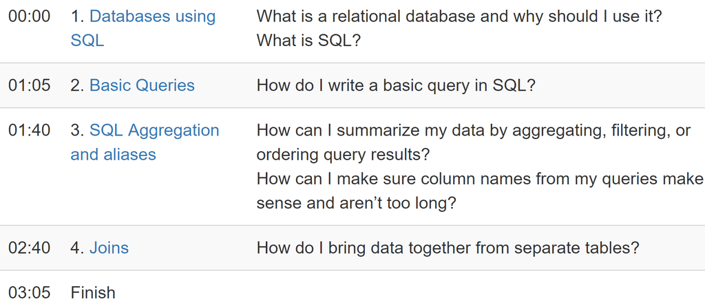

## 1. Databases using SQL (65’)

- What is a relational database and why bother?
- What is SQL?

## Challenge

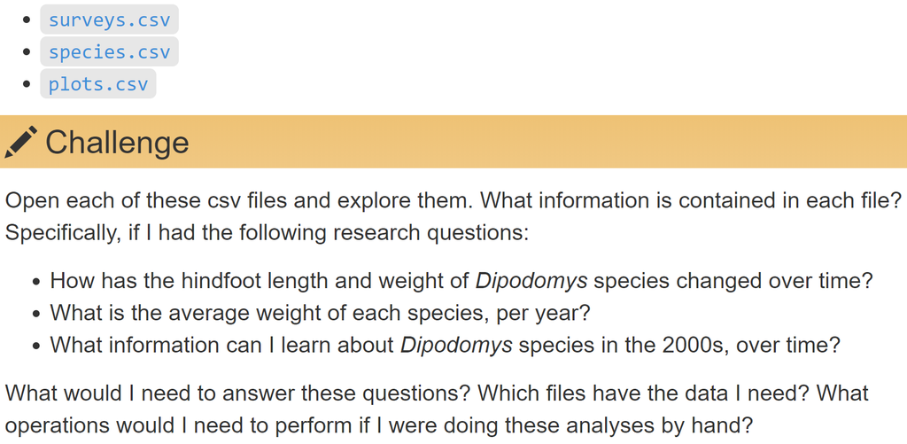

## Solution

Open and explore each file with the previous questions in mind.

[figure not shown]

## Relational data

Database: Collection of tables connected via some value.

Table; record (= observation = row); field (= column); key; unique identifier; entry (value).

[Source](http://r4ds.had.co.nz/relational-data.html)

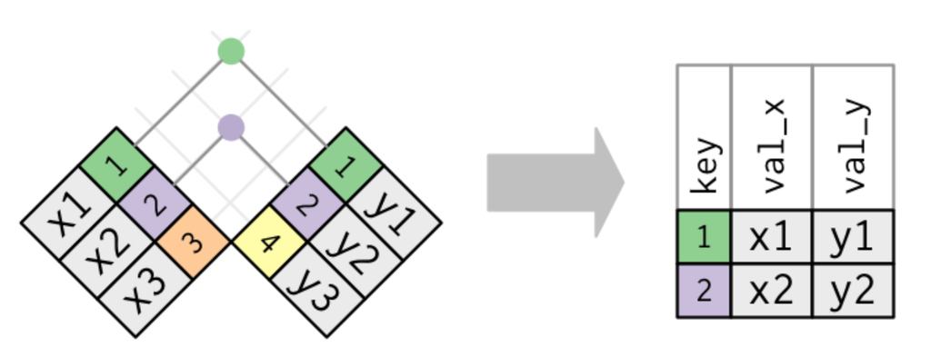

## Explore a database

[figure not shown]

## Explore a database

Explore all tabs. In *Database Structure*:

- Do types vary across columns of a table?
- Do types vary across rows of a column?

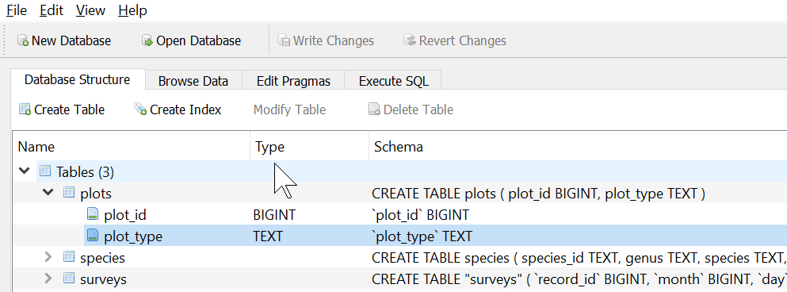

## Design

Is data redundant?

- Why would you design a database that way?
- How you can design a database to achieve that?

## Exercise

### Create a new database importing .csv files

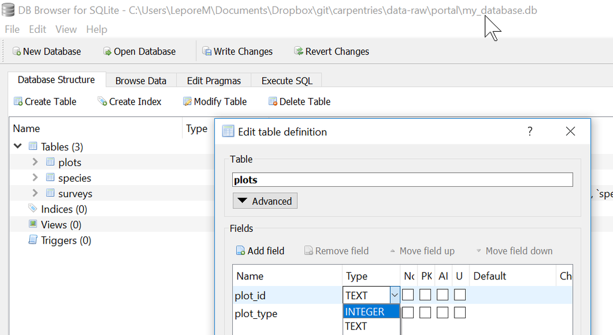

## Exercise

### Create a new database importing .csv files

Menu:

- *File > New Database*.
- *File > Import > Table from CSV file…*.
  - Import: surveys.csv, species.csv, plots.csv
- *Modify Table*
  - use INTEGER, REAL and TEXT (see next slide or [lesson](https://datacarpentry.org/sql-ecology-lesson/00-sql-introduction/index.html)).

## Exercise

### Column types

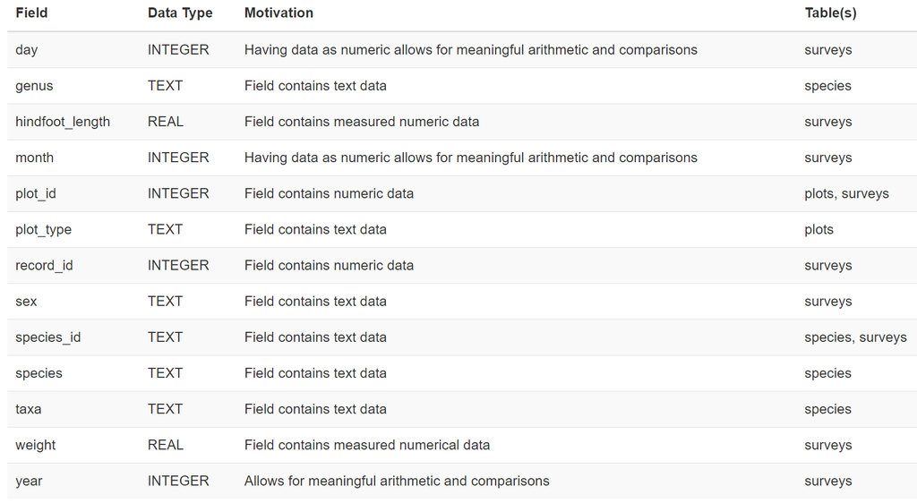

## Key point

- A database is a collection of tables related to each other by shared keys.

## Bonus: A database in sheets

[figure not shown]

## Bonus: A database in R

```r
library(here)
library(tidyverse)
```

Easiest is to work directly with the .csv files.

```r
plots   <- read_csv(here("plots.csv"))
species <- read_csv(here("species.csv"))
surveys <- read_csv(here("surveys.csv"))
```

## Bonus: A database in R

```r
surveys
## # A tibble: 35,549 x 9
##    record_id month   day  year plot_id species_id sex   hindfoot_length
##        <int> <int> <int> <int>   <int> <chr>      <chr>           <int>
##  1         1     7    16  1977       2 NL         M                  32
##  2         2     7    16  1977       3 NL         M                  33
##  3         3     7    16  1977       2 DM         F                  37
##  4         4     7    16  1977       7 DM         M                  36
##  5         5     7    16  1977       3 DM         M                  35
##  6         6     7    16  1977       1 PF         M                  14
##  7         7     7    16  1977       2 PE         F                  NA
##  8         8     7    16  1977       1 DM         M                  37
##  9         9     7    16  1977       1 DM         F                  34
## 10        10     7    16  1977       6 PF         F                  20
## # ... with 35,539 more rows, and 1 more variable: weight <int>
```

## Bonus: A database in R

If you already have a database, you can also use it.

```r
path <- here("data-raw/portal/portal_mammals.sqlite")
db <- DBI::dbConnect(RSQLite::SQLite(), path)
```

Copy each table from the database.

```r
plots_db   <- tbl(db, "plots")
species_db <- tbl(db, "species")
surveys_db <- tbl(db, "surveys")
```

## Bonus: A database in R

```r
surveys_db
## # Source:   table<surveys> [?? x 9]
## # Database: sqlite 3.22.0
## #   [C:\Users\LeporeM\Documents\Dropbox\git\carpentries\data-raw\portal\portal_mammals.sqlite]
##    record_id month   day  year plot_id species_id sex   hindfoot_length
##        <int> <int> <int> <int>   <int> <chr>      <chr>           <dbl>
##  1         1     7    16  1977       2 NL         M                  32
##  2         2     7    16  1977       3 NL         M                  33
##  3         3     7    16  1977       2 DM         F                  37
##  4         4     7    16  1977       7 DM         M                  36
##  5         5     7    16  1977       3 DM         M                  35
##  6         6     7    16  1977       1 PF         M                  14
##  7         7     7    16  1977       2 PE         F                  NA
##  8         8     7    16  1977       1 DM         M                  37
##  9         9     7    16  1977       1 DM         F                  34
## 10        10     7    16  1977       6 PF         F                  20
## # ... with more rows, and 1 more variable: weight <dbl>
```

## 2. Basic Queries (35’)

### How do I write a basic query in SQL?

## `SELECT <columns> FROM <table>`

### Different ways to select columns from a table:

```sql
SELECT *
FROM surveys;
```

```sql
SELECT year, month, day
FROM surveys;
```

```sql
SELECT surveys.year, surveys.month, surveys.day
FROM surveys;
```

## Syle

### *Execute SQL* (Cmd-Enter/Ctrl-Enter)

Good

```sql
SELECT year
FROM surveys;
```

Bad

```sql
select year from surveys;
```

## `LIMIT` and `DISTINCT`

```sql
SELECT *
FROM surveys
LIMIT 10;
```

```sql
SELECT DISTINCT species_id
FROM surveys;
```

## Calculated values

### `+`, `-`, `*`, `/`, and `ROUND(<what?>, <digits>)`

```sql
SELECT year, month, day, weight / 1000
FROM surveys;
```

```sql
SELECT plot_id, species_id, sex, weight, ROUND(weight / 1000, 2)
FROM surveys;
```

## `<INTEGER> / 1000`

Change `weight` to integer:

- *Database Structure > surveys > Modify Table* to INTEGER

```sql
SELECT weight / 1000
FROM surveys
```

```sql
SELECT weight / 1000.00
FROM surveys
```

Change back

## Challenge

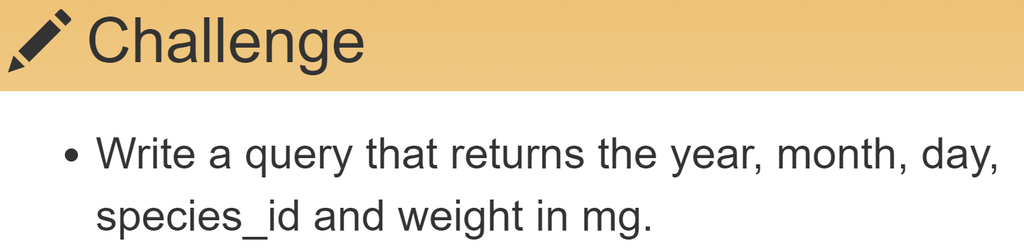

## Solution

```sql
SELECT day, month, year, species_id, weight * 1000
FROM surveys;
```

## Filtering with `WHERE`

```sql
SELECT *
FROM surveys
WHERE species_id = 'DM';
```

```sql
SELECT * FROM surveys
WHERE year >= 2000;
```

## Multiple conditions: `AND`, `OR`, and `IN`

```sql
SELECT *
FROM surveys
WHERE (year >= 2000) AND (species_id = 'DM');
```

```sql
SELECT *
FROM surveys
WHERE (species_id = 'DM') OR (species_id = 'DO') OR (species_id = 'DS');

-- Same as above. BTW, I'm a comment :)
SELECT *
FROM surveys
WHERE species_id IN ('DM', 'DO', 'DS');
```

## Challenge

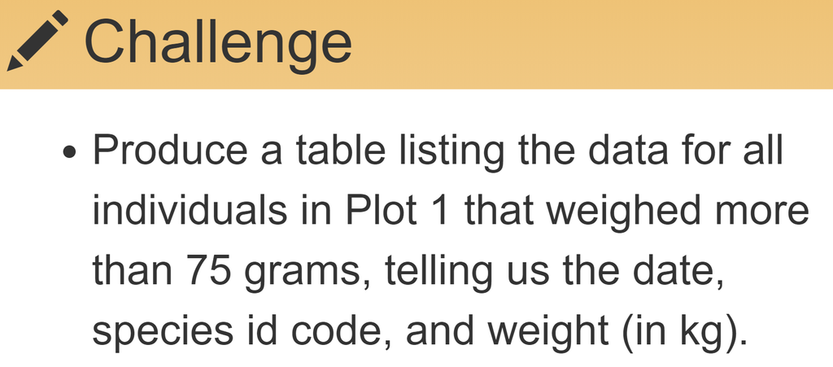

## Solution

```sql
SELECT day, month, year, species_id, weight / 1000
FROM surveys
WHERE (plot_id = 1) AND (weight > 75);
```

## Sorting: `ORDER BY <column> ASC/DESC`

```sql
SELECT *
FROM species
ORDER BY taxa ASC;
```

```sql
SELECT *
FROM species
ORDER BY taxa DESC;
```

```sql
SELECT *
FROM species
-- ASC is implicit (default).
ORDER BY genus, species;
```

## Challenge

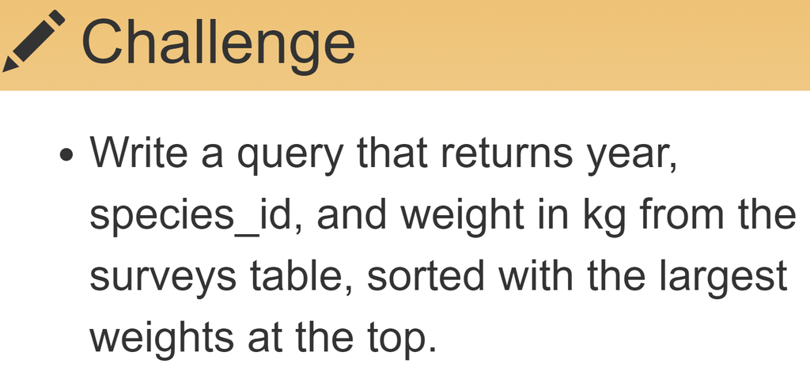

## Solution

```sql
SELECT year, species_id, weight / 1000
FROM surveys
ORDER BY weight DESC;
```

## Challenge

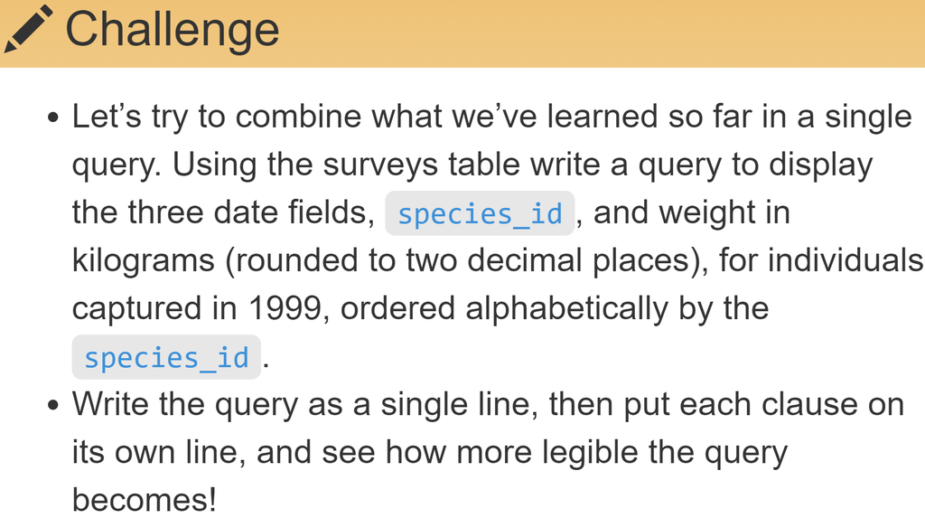

## Solution

```sql
SELECT year, month, day, species_id, ROUND(weight / 1000, 2)
FROM surveys
WHERE year = 1999
ORDER BY species_id;
```

## Key points

- “Good” style and comments make your code easier to understand.
- SQL helps you select columns, filter and order rows
- Pick specific rows using conditions with `AND`, `OR` and `IN`.
- Compute on column values with arithmetic operators.

## Bonus: Basic query in R

```r
surveys %>%
  mutate(weight_kg = round(weight / 1000, 2)) %>%
  select(year, month, day, species_id, weight_kg) %>%
  filter(year == 1999) %>%
  arrange(species_id) %>%
  # Show interesting rows
  filter(!is.na(weight_kg))
## # A tibble: 1,075 x 5
##     year month   day species_id weight_kg
##    <int> <int> <int> <chr>          <dbl>
##  1  1999     1    16 DM              0.04
##  2  1999     1    16 DM              0.05
##  3  1999     1    16 DM              0.05
##  4  1999     1    16 DM              0.04
##  5  1999     1    16 DM              0.05
##  6  1999     1    16 DM              0.04
##  7  1999     1    16 DM              0.05
##  8  1999     1    16 DM              0.04
##  9  1999     1    16 DM              0.04
## 10  1999     1    16 DM              0.05
## # ... with 1,065 more rows
```

## 3. SQL Aggregation and aliases (60’)

- How can I summarize my data by aggregating, filtering, or ordering query results?
- How can I make sure column names from my queries make sense and aren’t too long?

## `COUNT`, `MAX`, `MIN`, and `AVG`

### Some of the simplest, most informative summaries

```sql
SELECT COUNT(*)
FROM surveys;
```

```sql
SELECT COUNT(*), SUM(weight)
FROM surveys;
```

## Challenge

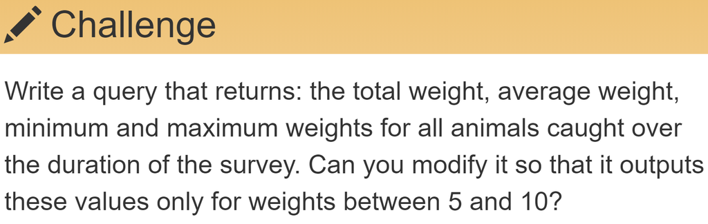

## Solution

```sql
-- All animals
SELECT SUM(weight), AVG(weight), MIN(weight), MAX(weight)
FROM surveys;

-- Only weights between 5 and 10
SELECT SUM(weight), AVG(weight), MIN(weight), MAX(weight)
FROM surveys
WHERE (weight > 5) AND (weight < 10);
```

## Grouped summaries with `GROUP BY`

```sql
SELECT species_id, COUNT(*)
FROM surveys
GROUP BY species_id;
```

## Challenge

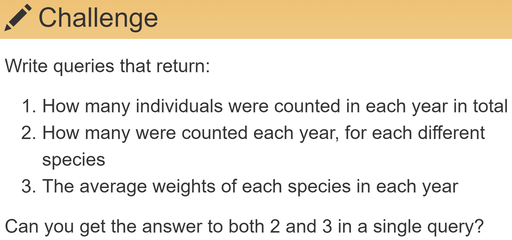

## Solution

Solution of 1

```sql
SELECT year, COUNT(*)
FROM surveys
GROUP BY year;
```

Solution of 2 and 3

```sql
SELECT year, species_id, COUNT(*), AVG(weight)
FROM surveys
GROUP BY year, species_id;
```

## `ORDER BY` a summary column

```sql
SELECT species_id, COUNT(*)
FROM surveys
GROUP BY species_id
ORDER BY COUNT(species_id);
```

## Clarify column names with `AS`

```sql
SELECT MAX(year) AS last_surveyed_year
FROM surveys;

SELECT MAX(year) last_surveyed_year
FROM surveys;
```

`AS` is optional. This also works (but isn’t “good” style)

```sql
SELECT MAX(year) last_surveyed_year
FROM surveys;
```

## `GROUP BY <cols> HAVING <cond>`

### Filter results of aggregate functions

`HAVING` ~ `WHERE`:

- `<columns> WHERE <condition>`
- `<results> HAVING <condition>`

## `GROUP BY <cols> HAVING <cond>`

### Filter results of aggregate functions

```sql
SELECT species_id, COUNT(species_id)
FROM surveys
GROUP BY species_id
-- "Smells" a bit
HAVING COUNT(species_id) > 10;

-- Same but nicer
SELECT species_id, COUNT(species_id) AS n
FROM surveys
GROUP BY species_id
HAVING n > 10;
```

http://rstd.io/code-smells (Jenny Bryan)

## Challenge

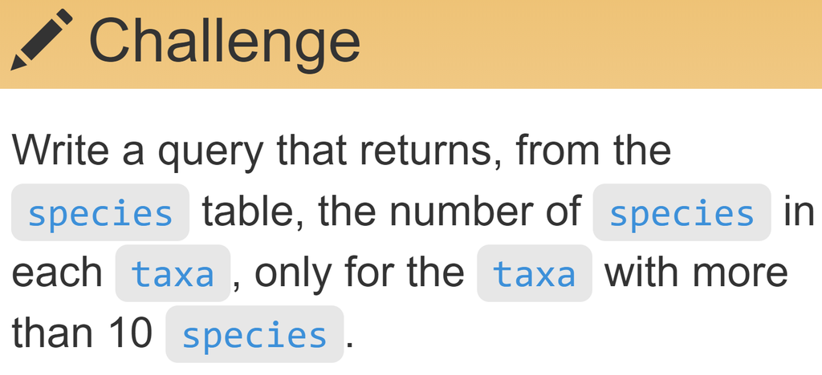

## Solution

```sql
SELECT taxa, COUNT(*) AS n
FROM species
GROUP BY taxa
HAVING n > 10;
```

## `CREATE VIEW viewname AS`

### Store and reuse queries

```sql
SELECT *
FROM surveys
WHERE year = 2000 AND (month > 4 AND month < 10);
```

Store

```sql
CREATE VIEW summer_2000 AS
SELECT *
FROM surveys
WHERE year = 2000 AND (month > 4 AND month < 10);
```

Reuse

```sql
SELECT *
FROM summer_2000
WHERE species_id == 'PE';
```

## Be careful with `NULL` values

```sql
-- 45 individuals which sex is of NULL sex
SELECT sex, COUNT(*)
FROM summer_2000
GROUP BY sex

-- As you expect, excludes NULL
SELECT COUNT(*)
FROM summer_2000
-- Excludes NULL
WHERE sex == 'F'

-- But tally includes NULL: 366 + 382 + 45 = 793
SELECT COUNT(*)
FROM summer_2000
```

## Key points

- Use `MIN`, `MAX`, `AVG`, `SUM`, `COUNT`, etc. to operate on aggregated data.
- Use `AS` to create aliases.
- Use `HAVING` to filter on aggregate properties (similar to `WHERE`).
- Use `CREATE VIEW` to store a query.

## Bonus: Aggregation and aliases

```r
surveys %>%
  group_by(species_id) %>%
  summarize(n = n()) %>%
  filter(n > 10)
## # A tibble: 30 x 2
##    species_id     n
##    <chr>      <int>
##  1 AB           303
##  2 AH           437
##  3 BA            46
##  4 CB            50
##  5 CM            13
##  6 CQ            16
##  7 DM         10596
##  8 DO          3027
##  9 DS          2504
## 10 DX            40
## # ... with 20 more rows
```

## Bonus: Aggregation and aliases

`count()` is so common that has a shortcut

[output not shown]

## 4. Joins (25’)

### How do I bring data together from separate tables?

## `JOIN <table> USING <(columns)>`

```sql
SELECT *
FROM surveys
JOIN species
ON surveys.species_id = species.species_id;
```

Same, when column names match.

```sql
SELECT *
FROM surveys
JOIN species
-- Same column name in both tables
USING (species_id);
```

## Challenge

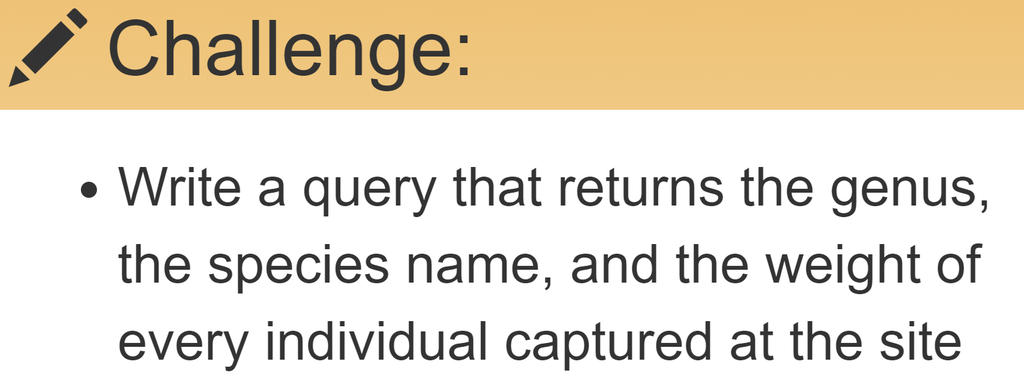

## Solution

```sql
SELECT species.genus, species.species, surveys.weight
FROM surveys
JOIN species
ON surveys.species_id = species.species_id;
```

Same

```sql
SELECT genus, species, weight
FROM surveys
JOIN species
USING (species_id)
```

## `<kind of> JOIN`

`INNER JOIN` = `JOIN`: Keeps all rows that match in both tables

```sql
SELECT *
FROM surveys
INNER JOIN species
USING (species_id);
```

`LEFT JOIN`: Keeps all rows that match in left table

(“left” is closest to `FROM`)

## Challenge

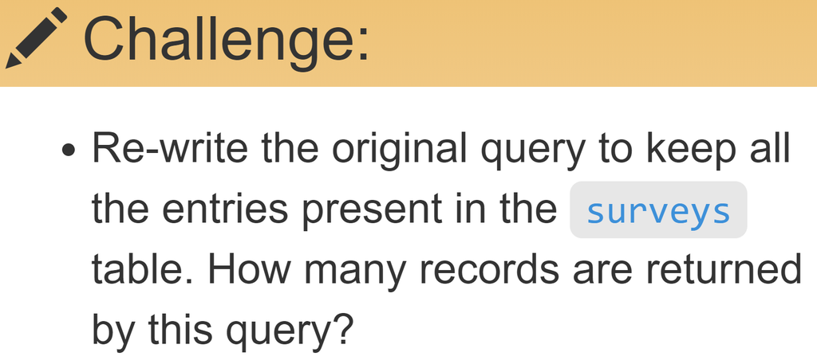

## Solution

```sql
SELECT *
FROM surveys
LEFT JOIN species
USING (species_id);
```

## Compute on `JOIN`ed results

### And a note on style

Left table implicit: Drives attention to `surveys.weight`.

```sql
SELECT plot_type, AVG(surveys.weight)
FROM plots
JOIN surveys
USING (plot_id)
GROUP BY plot_type;
```

Same but buries intention.

```sql
SELECT plots.plot_type, AVG(surveys.weight)
FROM surveys
JOIN plots
ON surveys.plot_id = plots.plot_id
GROUP BY plots.plot_type;
```

## Challenge

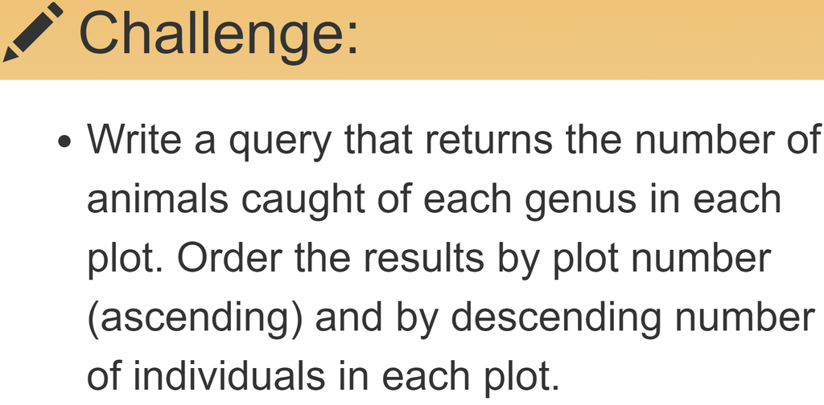

## Solution

```sql
SELECT plot_id, genus, COUNT(*) AS n
FROM surveys
JOIN species
USING (species_id)
GROUP BY genus, plot_id
ORDER BY plot_id ASC, n DESC;
```

## `IFNULL(<column>, <value>)`

### To “fill” `NULL` values

```sql
SELECT species_id, sex, IFNULL(sex, 'U')
FROM surveys;
```

## Challenge

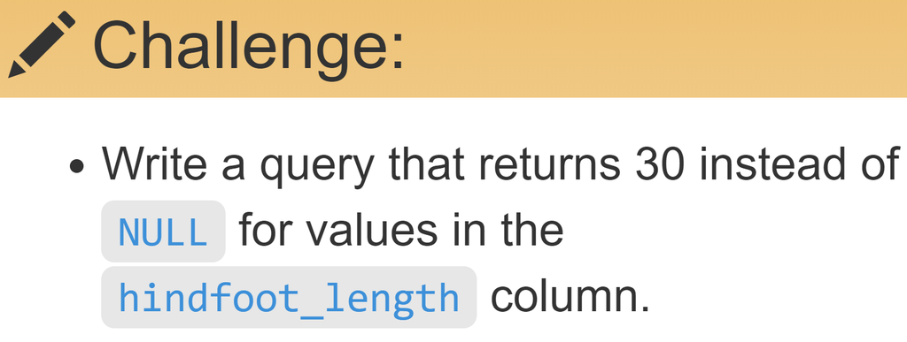

## Solution

```sql
SELECT hindfoot_length, IFNULL(hindfoot_length, 30)
FROM surveys;
```

## Challenge

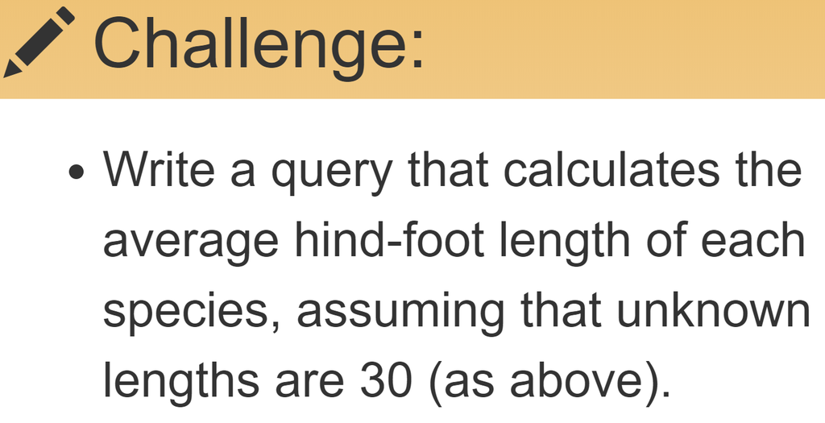

## Solution

```sql
SELECT species_id, AVG(IFNULL(hindfoot_length,30))
FROM surveys
GROUP BY species_id;
```

## `NULLIF(<column>, <value>)`

### to “null out” specific values

`NULLIF` is the inverse of `IFNULL`.

Returns `NULL`

If the first argument is equal to the second argument it returns `NULL`.

Else, it returns the original value.

```sql
SELECT species_id, plot_id, NULLIF(plot_id, 7)
FROM surveys;
```

## There are many more functions

### Example:

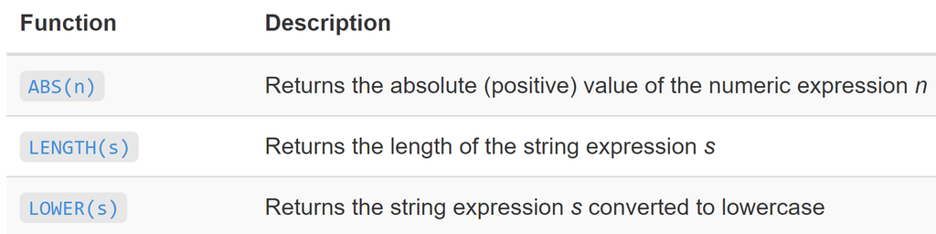

## Challenge

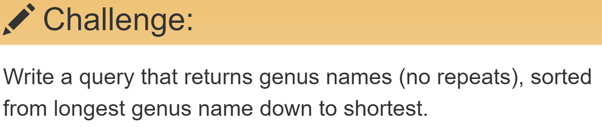

## Solution

```sql
SELECT genus, LENGTH(genus)
FROM species
ORDER BY LENGTH(genus) DESC
```

## Key points

- Use `JOIN <table> USING <(common column)>` to combine data from two tables.
- Use `(INNER) JOIN` to keep rows that match on both tables; or `LEFT JOIN` to keep all rows of the left table and the matching rows of the right table.
- Use `IFNULL(<column>, <value>)` to “fill” `NULL` values; and `NULLIF(<column>, <value>)` to “null out” specific values.
- Use other functions e.g. `LENGTH(<column>)` to operate on individual values.

## Bonus: Joins in R

```r
plots %>%
  left_join(surveys) %>%
  group_by(plot_type) %>%
  mutate(mean_weight = mean(weight, na.rm = TRUE)) %>%
  select(plot_type, mean_weight) %>%
  unique()
## Joining, by = "plot_id"
## # A tibble: 5 x 2
## # Groups:   plot_type [5]
##   plot_type                 mean_weight
##   <chr>                           <dbl>
## 1 Spectab exclosure                51.6
## 2 Control                          48.6
## 3 Long-term Krat Exclosure         27.2
## 4 Rodent Exclosure                 32.5
## 5 Short-term Krat Exclosure        41.2
```